# MAS451 ergasia 2025

Konstantinos Evagorou , Maria Prokopiou , Maria Theocharous , Alekos Liatsos

2025-10-29

```r
rm(list=ls())
graphics.off()
library(MASS)
library(leaps)
library(corrplot)
```

Φορτώνουμε τα δεδομένα. Έχουμε 156 παρατηρήσεις (χώρες). Η εξαρτημένη μεταβλητή Υ είναι το Happiness Score (Score) και είναι η 3η στήλη του data. Οι επόμενες στήλες αντιστοιχούν στις επεξηγηματικές μεταβλητές: GDP per capita (ΑΕΠ κατά κεφαλήν), Social support (κοινωνική υποστήριξη), Healthy life expectancy (υγιής προσδόκιμο ζωής), Freedom to make life choices (ελευθερία επιλογών(0-1)), Generosity (γενναιοδωρία), Perceptions of corruption (αντίληψη για τη διαφθορά).

Οι επεξηγηματικές μεταβλητές του World Happiness Report μετρώνται σε τυποποιημένες κλίμακες που κυμαίνονται περίπου μεταξυ 0 και1.5.

```r
data= read.csv('happiness_score.csv')
```

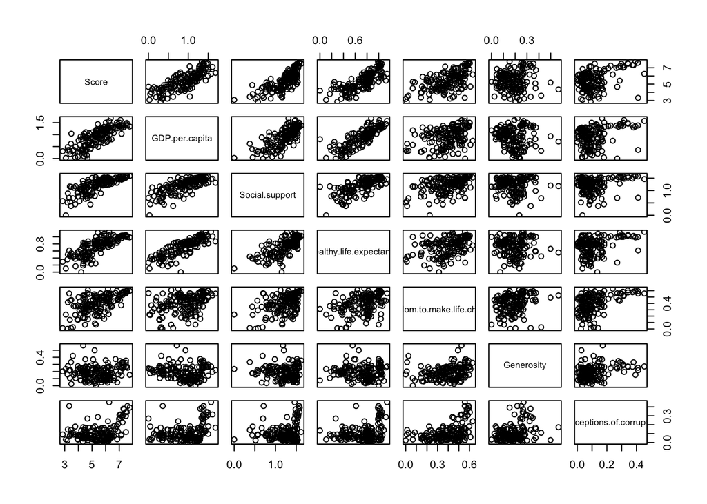

```r
new_data = data[, -c(1,2)]
pairs(new_data)
```

```r
round(cor(new_data , use='everything'),2)
```

```
##                              Score GDP.per.capita Social.support
## Score                         1.00           0.79           0.78
## GDP.per.capita                0.79           1.00           0.75
## Social.support                0.78           0.75           1.00
## Healthy.life.expectancy       0.78           0.84           0.72
## Freedom.to.make.life.choices  0.57           0.38           0.45
## Generosity                    0.08          -0.08          -0.05
## Perceptions.of.corruption     0.39           0.30           0.18
##                              Healthy.life.expectancy
## Score                                           0.78
## GDP.per.capita                                  0.84
## Social.support                                  0.72
## Healthy.life.expectancy                         1.00
## Freedom.to.make.life.choices                    0.39
## Generosity                                     -0.03
## Perceptions.of.corruption                       0.30
##                              Freedom.to.make.life.choices Generosity
## Score                                                0.57       0.08
## GDP.per.capita                                       0.38      -0.08
## Social.support                                       0.45      -0.05
## Healthy.life.expectancy                              0.39      -0.03
## Freedom.to.make.life.choices                         1.00       0.27
## Generosity                                           0.27       1.00
## Perceptions.of.corruption                            0.44       0.33
##                              Perceptions.of.corruption
## Score                                             0.39
## GDP.per.capita                                    0.30
## Social.support                                    0.18
## Healthy.life.expectancy                           0.30
## Freedom.to.make.life.choices                      0.44
## Generosity                                        0.33
## Perceptions.of.corruption                         1.00
```

Πιο πάνω κάνουμε γράφημα διασποράς (scatter plot) των δεδομένων και υπολογίζουμε τον δειγματικό συντελεστή συσχέτισης ανάμεσα στις διάφορες μεταβλητές. Παρατηρούμε ότι υπάρχουν ισχυρές θετικές συσχετίσεις μεταξύ του Happiness Score και των μεταβλητών GDP per capita (0.79), Social support (0.78) και Healthy life expectancy (0.78). Αντίθετα, η μεταβλητή Generosity έχει πολυ ασθενείς συσχετισείς με το Happiness Score (0.08) και οι υπόλοιπες έχουν μέτριες συσχετισεις. Επίσης, φαίνετε να υπάρχουν συσχετίσεις μεταξυ επεξηγηματικών μεταβλητών, με τις πιο υψηλές να είναι μεταξύ των GDP per capita, Social support και Healthy life expectancy. Οι συσχετίσεις μεταξύ των ανεξάρτητων μεταβλητών μου GDP - Social είναι 0.75, μεταξύ GDP - Health είναι 0.84, μεταξύ Health - Social είναι 0.72 και αυτή η συσχέτιση μας δείχνει ότι έχουμε πολυσυγγραμμικότητα, η οποία επηρεάζει τις διακυμάνσεις των επιμέρους συντελεστών παλινδρόμησης βήτα και άρα την ερμηνεία της συμβολής τους στο μοντέλο.

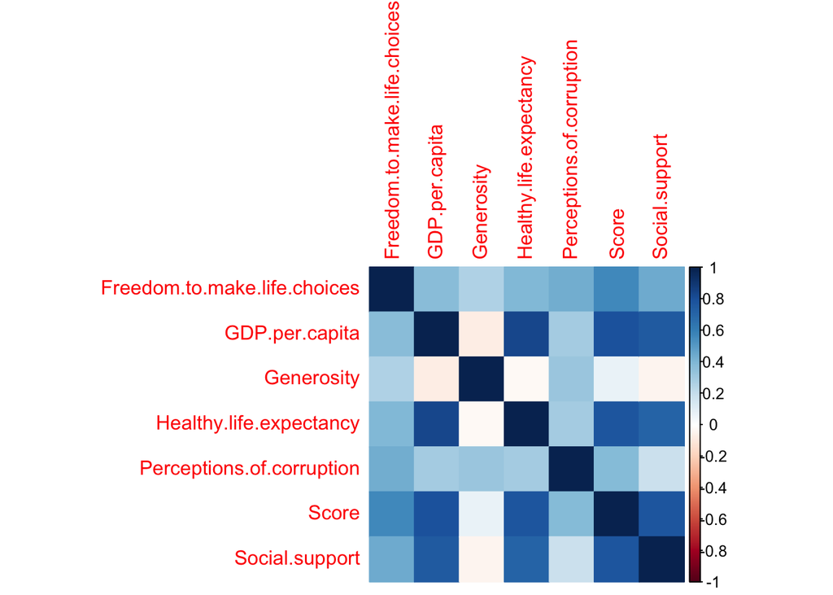

```r
Z <- cor(new_data)
corrplot(Z , method="color" , order = "alphabet")
```

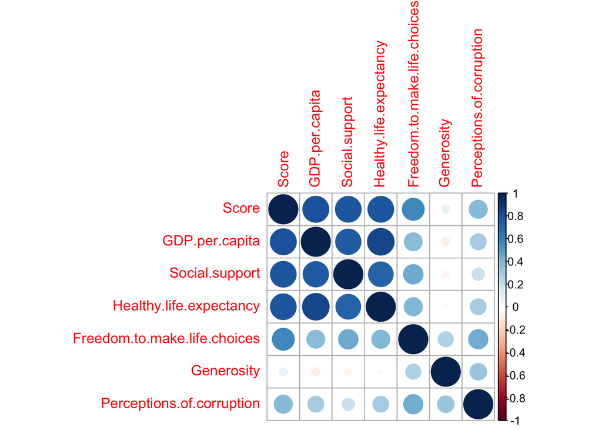

```r
corrplot(Z)
```

Βλέπουμε την οπτικοποίηση του πίνακα συσχετίσεων.Παρατηρούμε ότι το Score έχει ισχυρές θετικές συσχετίσεις με οικονομικούς και κοινωνικούς δείκτες (GDP, Social support, Health).

Προσαρμόζουμε το πολλαπλό γραμμικό μοντέλο.

```r
lm.full <- lm(Score~ .,new_data)
summary(lm.full)
```

```
##
## Call:
## lm(formula = Score ~ ., data = new_data)
##
## Residuals:
##      Min       1Q   Median       3Q      Max
## -1.75304 -0.35306  0.05703  0.36695  1.19059
##
## Coefficients:
##                              Estimate Std. Error t value Pr(>|t|)
## (Intercept)                    1.7952     0.2111   8.505 1.77e-14 ***
## GDP.per.capita                 0.7754     0.2182   3.553 0.000510 ***
## Social.support                 1.1242     0.2369   4.745 4.83e-06 ***
## Healthy.life.expectancy        1.0781     0.3345   3.223 0.001560 **
## Freedom.to.make.life.choices   1.4548     0.3753   3.876 0.000159 ***
## Generosity                     0.4898     0.4977   0.984 0.326709
## Perceptions.of.corruption      0.9723     0.5424   1.793 0.075053 .
## ---
## Signif. codes:  0 '***' 0.001 '**' 0.01 '*' 0.05 '.' 0.1 ' ' 1
##
## Residual standard error: 0.5335 on 149 degrees of freedom
## Multiple R-squared:  0.7792, Adjusted R-squared:  0.7703
## F-statistic: 87.62 on 6 and 149 DF,  p-value: < 2.2e-16
```

Αρχικά, παρατηρούμε ότι το p-value του ελέγχου F (=87.62) (ύπαρξη παλινδρόμησης) είναι πολύ μικρό (< 2.2e-16), άρα απορρίπτουμε την μηδενική υπόθεση. Επομένως το μοντέλο συνολικά είναι στατιστικά σημαντικό και τουλάχιστον μία ανεξάρτητη μεταβλητή εξηγεί το Happiness score. Το γραμμικό μοντέλο εξηγεί το 77.92% της μεταβλητότητας του Happiness score (Multiple R² = 0.7792, Adjusted R² = 0.7703), γεγονός που δείχνει ότι οι μεταβλητές δίνουν καλή εξήγηση της διαφοροποίησης της ευτυχίας μεταξυ των χωρών.Η διαφορά του R² με το adjusted R² είναι 0.0089, πράγμα που δείχνει μια σταθερότητα στο μοντέλο. Επίσης, το γεγονός ότι το R² και το adjusted R² είναι τόσο κοντά δείχνει ότι οι περισσότερες από τις μεταβλητές που συμπεριλαμβάνουμε είναι πραγματικά χρήσιμες και συμβάλλουν σημαντικά στην εξήγηση της μεταβλητότητας της εξαρτημένης μεταβλητής.

Οι μεταβλητές που είναι στατιστικά σημαντικές (p-value < 0.05) είναι: GDP per capita (p=0.000510), Social support (p = 4.83e-06), Healthy life expectancy (p=0.001560), Freedom to make life choices (p = 0.000159). Η μεταβλητή Generosity δεν είναι στατιστικά σημαντική p=0.326709,ενώ η Perceptions of corruption δεν είναι οριακά p=0.075053.

Το Residual standard error είναι 0.5335, που δείχνει ότι οι περισσότερές προβλέψεις απέχουν κατα μέσο όρο περίπου 0.5335 μονάδες από τις πραγματικές τιμές του Happiness score. Αυτό υποδηλώνει ότι το μοντέλο παρέχει σχετικά ακριβείς προβλεψεις.

Πριν προχωρήσουμε στην επιλογή μοντέλου, ελέγχουμε τις υποθέσεις του γραμμικού μοντέλου.

```r
names(lm.full)
```

```
##  [1] "coefficients"  "residuals"     "effects"       "rank"
##  [5] "fitted.values" "assign"        "qr"            "df.residual"
##  [9] "xlevels"       "call"          "terms"         "model"
```

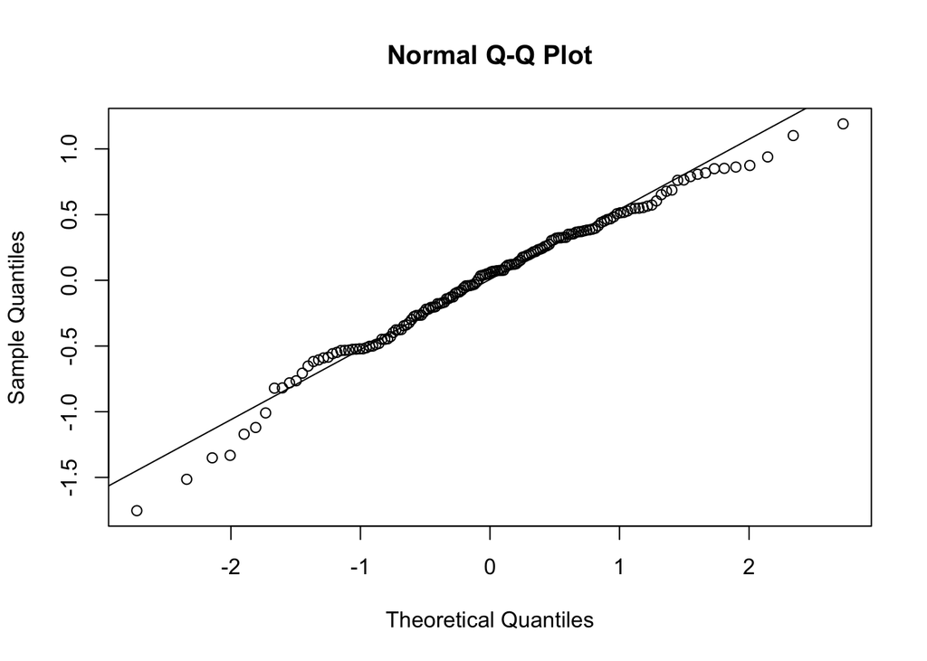

```r
residuals.state = lm.full$residuals
qqnorm(residuals.state)
qqline(residuals.state)
```

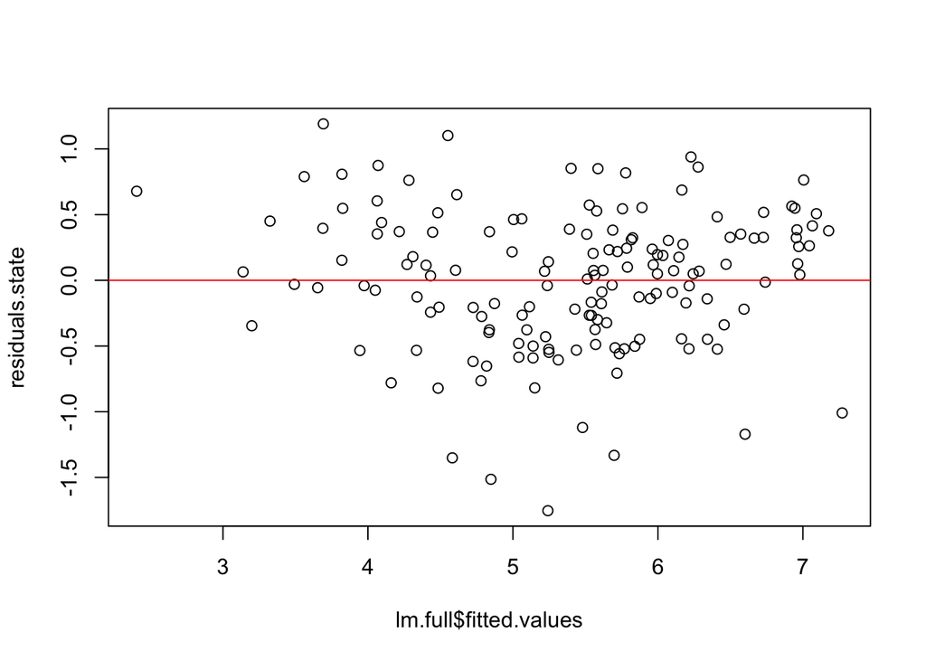

```r
plot(lm.full$fitted.values , residuals.state)
abline(h=0 , col='red')
```

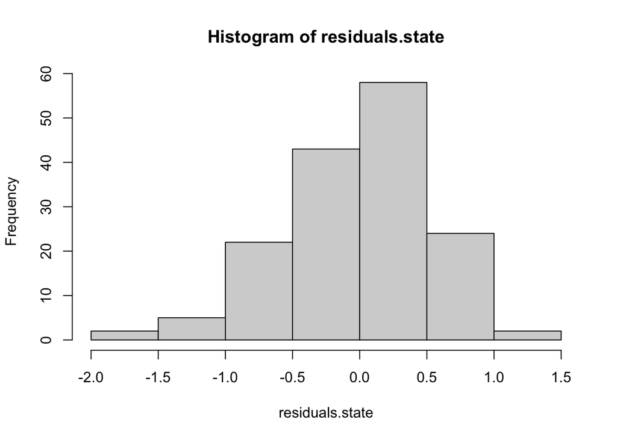

```r
hist(residuals.state)
```

Βλέπουμε ότι στα διαγνωστικά γραφήματα, τα διατεταγμένα υπόλοιπα στο Q-Q plot δείχνουν κάποιες αποκλίσεις από την ευθεία, ειδικά στα ακραία σημεία, γεγονός που υποδηλώνει ότι η κατανομή των υπολοίπων αποκλίνει ελαφρώς από την κανονική κατανομή. Παρόλα αυτά, για τα περισσότερα δεδομένα η προσέγγιση κανονικότητας είναι ικανοποιητική. Στο γράφημα των υπολοίπων έναντι των προσαρμοσμένων τιμών, παρατηρούμε ότι τα σφάλματα είναι τυχαία διασκορπισμένα γύρω από το μηδέν, χωρίς εμφανή μοτίβο, γεγονός που υποστηρίζει την υπόθεση της σταθερής διασποράς και της ανεξαρτησίας των σφαλμάτων. Η γραμμή στο μηδέν βοηθά στον οπτικό έλεγχο αυτής της υπόθεσης.

Πρώτα, θα χρησιμοποιήσουμε τη Μέθοδο Επιλογής Βέλτιστου Υποσυνόλου.

```r
bss <- regsubsets(Score~ .,new_data , nvmax=6 )

bss.summary = summary(bss)
summary(bss)
```

```
## Subset selection object
## Call: regsubsets.formula(Score ~ ., new_data, nvmax = 6)
## 6 Variables  (and intercept)
##                              Forced in Forced out
## GDP.per.capita                   FALSE      FALSE
## Social.support                   FALSE      FALSE
## Healthy.life.expectancy          FALSE      FALSE
## Freedom.to.make.life.choices     FALSE      FALSE
## Generosity                       FALSE      FALSE
## Perceptions.of.corruption        FALSE      FALSE
## 1 subsets of each size up to 6
## Selection Algorithm: exhaustive
##          GDP.per.capita Social.support Healthy.life.expectancy
## 1  ( 1 ) "*"            " "            " "
## 2  ( 1 ) "*"            " "            " "
## 3  ( 1 ) "*"            "*"            " "
## 4  ( 1 ) "*"            "*"            "*"
## 5  ( 1 ) "*"            "*"            "*"
## 6  ( 1 ) "*"            "*"            "*"
##          Freedom.to.make.life.choices Generosity Perceptions.of.corruption
## 1  ( 1 ) " "                          " "        " "
## 2  ( 1 ) "*"                          " "        " "
## 3  ( 1 ) "*"                          " "        " "
## 4  ( 1 ) "*"                          " "        " "
## 5  ( 1 ) "*"                          " "        "*"
## 6  ( 1 ) "*"                          "*"        "*"
```

Η μέθοδος υπολογίζει όλα τα δυνατά υποσύνολα των ανεξάρτητων μεταβλητών και επιλέγει για κάθε μέγεθος μοντέλου (1-6 μεταβλητές) εκείνο που επιτυγχάνει την καλύτερη προσαρμογή (μικρότερο SSres).

Ο παρακάτω πίνακας δείχνει ποιες μεταβλητές περιλαμβάνονται στο καλύτερο μοντέλο για κάθε αριθμό μεταβλητών:

- Για 1 μεταβλητή: το μοντέλο περιλαμβάνει μόνο την GDP per capita
- Για 2 μεταβλητές: προστίθεται η Freedom to make life choices
- Για 3 μεταβλητές: προστίθεται η Social support
- Για 4 μεταβλητές: προστίθεται η Healthy life expectancy
- Για 5 μεταβλητές: προστίθεται η Perceptions of corruption
- Για 6 μεταβλητές: προστίθεται η Generosity

Παρατηρούμε ότι τα καλύτερα μοντέλα που προκύπτουν είναι εμφωλιασμένα, αυτό υποδηλώνει ότι το βέλτιστο σύνολο μεταβλητών αυξάνεται με σταθερό και συνεπή τρόπο. Πιο κάτω κάνουμε γράφημα των τιμών των κριτηρίων για τα καλύτερα μοντέλα

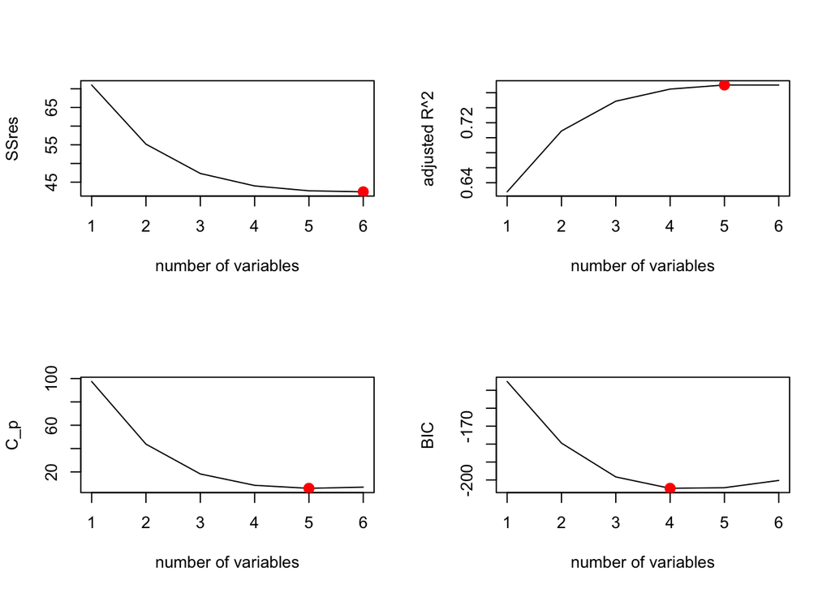

```r
par(mfrow= c(2,2))

plot(bss.summary$rss , xlab='number of variables', ylab='SSres' , type="l")
k0 = which.min(bss.summary$rss)
points(k0 , bss.summary$rss[k0], col='red' , cex=2 , pch=20)

plot(bss.summary$adjr2, xlab='number of variables' , ylab='adjusted R^2', type="l")
k1=which.max(bss.summary$adjr2)
points(k1 , bss.summary$adjr2[k1], col='red' , cex=2, pch=20)

plot(bss.summary$cp, xlab='number of variables' , ylab='C_p', type="l")
k2=which.min(bss.summary$cp)
points(k2 , bss.summary$cp[k2], col='red' , cex=2, pch=20)

plot(bss.summary$bic , xlab='number of variables', ylab='BIC' , type ='l' )
K3=which.min(bss.summary$bic)
points(K3, bss.summary$bic[K3], col="red",cex=2,pch=20)
```

Είναι προφανές ότι το καλύτερο μέγεθος μοντέλου με κριτήριο το SSres είναι το πλήρες μοντέλο (p=6), καθώς το RSS ελαχιστοποιείται όταν περιλαμβάνονται όλες οι διαθέσιμες μεταβλητές. Επίσης τα καλύτερα μεγέθη μοντέλων με Cp και AIC είναι τα ίδια για γραμμικά μοντέλα με κανονικά σφάλματα όπως γνωρίζουμε (γι’αυτό δεν δείχνουμε το AIC εδώ). Ακόμη, παρατηρούμε ότι το Adjusted R² δίνει το ίδιο βέλτιστο μέγεθος με το Cp (p=5). Με BIC έχουμε βέλτιστο μέγεθος μοντέλου p=4. Γενικά γνωρίζουμε ότι το BIC είναι μικρότερου ή ίσου μεγέθους βέλτιστο μοντέλο από Cp/AIC (p=5). Η διαφορά στο βέλτιστο μέγεθος μεταξύ των κριτηρίων οφείλεται στο ότι το BIC επιβάλλει μεγαλύτερη ποινή για κάθε πρόσθετη μεταβλητή, επιλέγοντας έτσι ένα πιο απλό μοντέλο.

Μέχρι εδώ βρήκαμε το καλύτερο μέγεθος με κάθε κριτήριο: - SSres: 6 μεταβλητές (πλήρες μοντέλο) - Adjusted R²: 5 μεταβλητές - Cp: 5 μεταβλητές - BIC: 4 μεταβλητές

Για να δούμε ποιο ακριβώς είναι το μοντέλο, πρέπει να πάμε στον πίνακα με τα καλύτερα μοντέλα κάθε μεγέθους, που μας εμφανίζει το summary.

Συμπέρασμα από πίνακα summary:

Το καλύτερο μοντέλο των κριτηρίων Adjusted R² και Cp (p=5) περιλαμβάνει τις επεξηγηματικές μεταβλητές: GDP per capita, Freedom to make life choices, Social support, Helthy life expectancy, Perception of corruption.

Το καλύτερο μοντέλο του κριτηρίου BIC (p=4) περιλαμβάνει τις επεξηγηματικές μεταβλητές: GDP per capita, Freedom to make life choices, Social support, Helthy life expectancy.

Εναλλακτικά, μπορούμε να δούμε τα καλύτερα μοντέλα σύμφωνα με τα διάφορα κριτήρια με την εντολή plot της regsubs

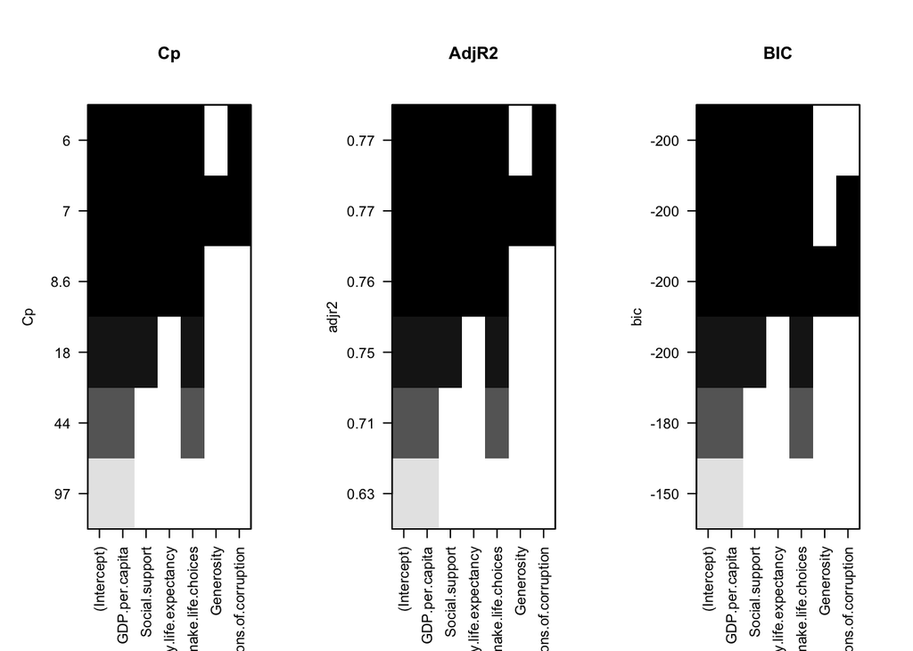

```r
par(mfrow=c(1,3))
plot(bss,scale='Cp')
title('Cp')
plot(bss, scale = "adjr2")
title("AdjR2")
plot(bss, scale = "bic")
title("BIC")
```

Παραλείπουμε τον έλεγχο με το SSres εφόσον επιλέγει πάντα το πλήρες μοντέλο. Τα γραφήματα δείχνουν με μαύρο τετράγωνο ποιες μεταβλητές περιλαμβάνονται στο βέλτιστο μοντέλο για κάθε κριτήριο. Παρατηρούμε ότι προκύπτουν τα ίδια αποτελέσματα όπως πιο πάνω. Από τα γραφήματα των κριτηρίων Cp, Adjusted R² και BIC, επιβεβαιώνουμε ότι:

- Για τα κριτήρια Cp και Adjusted R², το βέλτιστο μοντέλο περιλαμβάνει τις 5 μεταβλητές GDP per capita, Freedom to make life choices, Social support, Helthy life expectancy, Perception of corruption.
- Για το κριτήριο BIC, το βέλτιστο μοντέλο περιλαμβάνει τις 4 μεταβλητές: GDP per capita, Freedom to make life choices, Social support, Helthy life expectancy.

Παρατηρούμε ότι οι μεταβλητές: GDP per capita, Freedom to make life choices, Social support, Helthy life expectancy εμφανίζονται σε όλα τα βέλτιστα μοντέλα ανεξάρτητα από το κριτήριο, γεγονός που υποδηλώνει τη σημαντική τους συμβολή στην πρόβλεψη του Happiness Score.

Οι αντίστοιχες εκτιμήτριες των συντελεστών παλινδρόμησης βρίσκονται ως εξής

```r
coef(bss,5) #arithmos metavliton
```

```
##                  (Intercept)               GDP.per.capita
##                    1.8688725                    0.7454527
##               Social.support      Healthy.life.expectancy
##                    1.1180315                    1.0840162
## Freedom.to.make.life.choices    Perceptions.of.corruption
##                    1.5340094                    1.1175531
```

Αν εφαρμόσουμε τη μέθοδο προς τα εμπρός επιλογής με κριτήριο με penalty στην πολυπλοκότητα, το αποτέλεσμα θα είναι το ίδιο εφόσον τα καλύτερα μοντέλα που προκύπτουν απο την μέθοδο βέλτιστου υποσυνόλου είναι εμφωλιασμένα.

Εφαρμόζουμε την μέθοδο προς τα πίσω επιλογης.

```r
fs=regsubsets(Score~.,new_data, method="backward",nvmax=6)
fs.summary=summary(fs)
summary(fs)
```

```
## Subset selection object
## Call: regsubsets.formula(Score ~ ., new_data, method = "backward",
##     nvmax = 6)
## 6 Variables  (and intercept)
##                              Forced in Forced out
## GDP.per.capita                   FALSE      FALSE
## Social.support                   FALSE      FALSE
## Healthy.life.expectancy          FALSE      FALSE
## Freedom.to.make.life.choices     FALSE      FALSE
## Generosity                       FALSE      FALSE
## Perceptions.of.corruption        FALSE      FALSE
## 1 subsets of each size up to 6
## Selection Algorithm: backward
##          GDP.per.capita Social.support Healthy.life.expectancy
## 1  ( 1 ) "*"            " "            " "
## 2  ( 1 ) "*"            " "            " "
## 3  ( 1 ) "*"            "*"            " "
## 4  ( 1 ) "*"            "*"            "*"
## 5  ( 1 ) "*"            "*"            "*"
## 6  ( 1 ) "*"            "*"            "*"
##          Freedom.to.make.life.choices Generosity Perceptions.of.corruption
## 1  ( 1 ) " "                          " "        " "
## 2  ( 1 ) "*"                          " "        " "
## 3  ( 1 ) "*"                          " "        " "
## 4  ( 1 ) "*"                          " "        " "
## 5  ( 1 ) "*"                          " "        "*"
## 6  ( 1 ) "*"                          "*"        "*"
```

Το nvmax=6 είναι ο μέγιστος αριθμός μεταβλητών που εξετάζει η συνάρτηση για τα υποσύνολονα. Παρατηρούμε ότι στην προκειμένη περίπτωση, έχουμε το ΙΔΙΟ αποτέλεσμα με την μέθοδο βέλτιστου υποσυνόλου, πράγμα που δεν είναι πάντα αναμενόμενο. Στη συγκεκριμένη ανάλυση, και οι δύο μέθοδοι επιλέγουν τα ίδια ακριβώς μοντέλα για κάθε μέγεθος:

- Για 1 μεταβλητή: το μοντέλο περιλαμβάνει μόνο την GDP per capita
- Για 2 μεταβλητές: προστίθεται η Freedom to make life choices
- Για 3 μεταβλητές: προστίθεται η Social support
- Για 4 μεταβλητές: προστίθεται η Healthy life expectancy
- Για 5 μεταβλητές: προστίθεται η Perceptions of corruption
- Για 6 μεταβλητές: προστίθεται η Generosity

Αυτή η σύμπτωση οφείλεται πιθανώς στο μικρό αριθμό μεταβλητών (6) και στη σχετικά απλή δομή των δεδομένων. Σε μεγαλύτερα και πιο πολύπλοκα προβλήματα, οι δύο μέθοδοι μπορεί να δίνουν διαφορετικά αποτελέσμασματα.

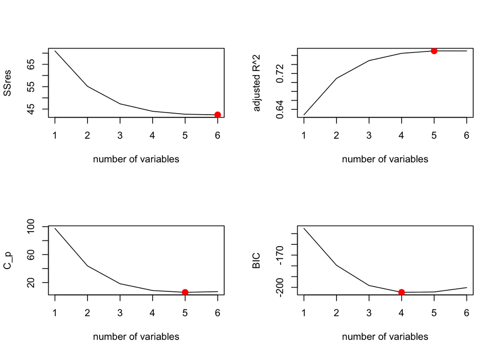

```r
par(mfrow= c(2,2))
#ftiaxno ena 2x2 pinaka gramikon parastaseon
plot(fs.summary$rss , xlab='number of variables', ylab='SSres' , type="l")
k0 = which.min(fs.summary$rss)
points(k0 , fs.summary$rss[k0], col='red' , cex=2 , pch=20)

plot(fs.summary$adjr2, xlab='number of variables' , ylab='adjusted R^2', type="l")
k1=which.max(fs.summary$adjr2)
points(k1 , fs.summary$adjr2[k1], col='red' , cex=2, pch=20)

plot(fs.summary$cp, xlab='number of variables' , ylab='C_p', type="l")
k2=which.min(fs.summary$cp)
points(k2 , fs.summary$cp[k2], col='red' , cex=2, pch=20)

plot(fs.summary$bic , xlab='number of variables', ylab='BIC' , type ='l' )
K3=which.min(fs.summary$bic)
points(K3, fs.summary$bic[K3], col="red",cex=2,pch=20)
```

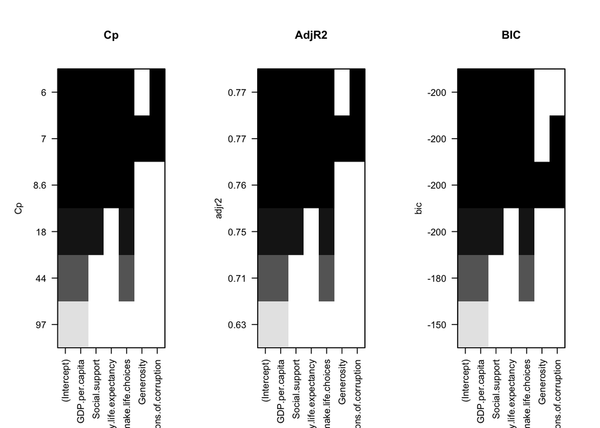

```r
par(mfrow=c(1,3))
plot(fs,scale='Cp')
title('Cp')
plot(fs, scale = "adjr2")
title("AdjR2")
plot(fs, scale = "bic")
title("BIC")
```

Παρατηρούμε ότι η μέθοδος προς τα πίσω επιλογής και η βέλτιστη υποσυνόλου δίνουν ακριβώς τα ίδια μοντέλα για κάθε μέγεθος.

Έπειτα, βρίσκουμε το μέγεθος του βέλτιστου υποσυνόλου χρησιμοποιώντας Cross-Validation.

```r
predict.regsubsets=function(object ,newdata ,id ,...){
  form=as.formula(object$call[[2]])
  mat=model.matrix(form ,newdata)
  coefi=coef(object,id=id)
  xvars=names(coefi)
  return(mat[,xvars]%*%coefi)
}
```

```r
K=5 # xorizei ta dedomena se folds
q=6 # arithmos metavliton sto plires montelo
set.seed(1)
```

Πρώτα διαμερίζουμε τα δεδομένα (training) σε Κ τυχαία υποσύνολα περίπου ίσου μεγέθους. Αυτό το κάνουμε παίρνοντας n ομοιόμορφα δείγματα με επανάθεση από το σύνολο {1,..,K}

```r
folds = sample(1:K , nrow(new_data),replace=TRUE)
```

Δημιουργούμε ενα πίνακα διάστασης Kxq, μέσα στον οποίο θα βάλουμετα σφάλματα.

```r
cv.errors=matrix(NA,K,q,dimnames=list(NULL, paste(1:q)))
```

Στη συνέχεια γεμίζουμε τα στοιχεία του πίνακα σφαλμάτων, γραμμή προς γραμμή.

```r
for(k in 1:K){
  bss.cv = regsubsets(Score ~ .,
                     data = new_data[folds != k, ],
                     nvmax = q)
  for(p in 1:q){
    cv.pred = predict(bss.cv, new_data[folds == k, ], id = p)
    cv.errors[k, p] = mean((new_data$Score[folds == k] - cv.pred)^2)
  }
}
```

Για να βρούμε το βέλτιστο μέγεθος, θα βρούμε τους μέσους όρους των σφαλμάτων για κάθε μέγεθος p, δηλαδή τους μέσους όρους των στηλών του πίνακα σφαλμάτων για το κάθε μέγεθος

```r
mean.cv.errors = apply(cv.errors,2,mean)
mean.cv.errors
```

```
##         1         2         3         4         5         6
## 0.4727387 0.4113946 0.3572321 0.3014467 0.3066721 0.3013044
```

Κάνουμε γράφημα των μέσων σφαλμάτων κάθε μεγέθους.

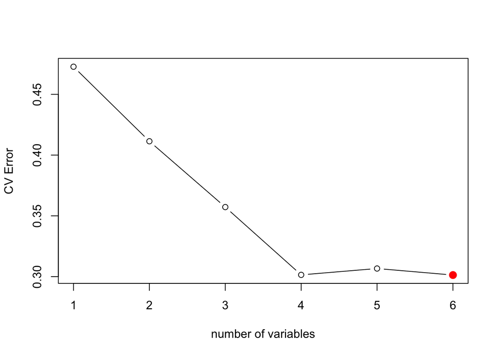

```r
plot(mean.cv.errors, type = 'b', xlab = "number of variables", ylab = "CV Error")
p.cv <- which.min(mean.cv.errors)
points(p.cv, mean.cv.errors[p.cv], col = "red", cex = 2, pch = 20)
```

Τα CV errors για κάθε μέγεθος μοντέλου είναι: - 1 μεταβλητή: 0.4727387 - 2 μεταβλητές: 0.4113946  
- 3 μεταβλητές: 0.3572321 - 4 μεταβλητές: 0.3014467 - 5 μεταβλητές: 0.3066721 - 6 μεταβλητές: 0.3013044 ← Βέλτιστο

Τα αποτελέσματα δείχνουν ότι το σφάλμα πρόβλεψης μειώνεται σταθερά καθώς αυξάνεται το μέγεθος του μοντέλου μέχρι τις 4 μεταβλητές. Όμως το μονέλο με 5 μεταβλητές παρουσιάζει ελαφρώς χειρότερη επίδοση,γεγονός που υποδηλώνει ότι η προσθήκη της 5ης μεταβλητής δεν βελτιώνει την πρόβλεψη. Παρατηρούμε ότι το μικρότερο σφάλμα επιτυγχάνεται με το μοντέλο με μέγεθος 6 μεταβλητών, αν και η βελτίωση σε σχέση με το μονέλο με 4 μεταβλητές είναι οριακή, το οποίο φαίνεται και από την γραφική παράσταση των μέσων σφαλμάτων (CVerr.4 = 0.3014467, CVerr.6 = 0.3013044 - διαφέρει 0.047%).

Βρίσκουμε τις 4 επεξηγηματικές μεταβλητές με την μέθοδο Βέλτιστου Υποσυνόλου από πριν, οι οποίες είναι: GDP per capita, Freedom to make life choices, Social support, Healthy life expectancy Με 5 προστίθεται η Perceptions of corruption. Επομένως η προσθήκη της μεταβλητής Perceptions of corruption δεν βελτιώνει την πρόβλεψη. Με 6 μεταβλητές προστίθεται η Generosity.

```r
predict.regsubsets.backward = function(object, newdata, id, ...) {
  form = as.formula(object$call[[2]])
  mat = model.matrix(form, newdata)
  coefi = coef(object, id = id)
  xvars = names(coefi)
  mat[, xvars] %*% coefi
}


set.seed(1)
K <- 5
q <- 6
folds <- sample(1:K, nrow(new_data), replace = TRUE)


cv.errors.backward <- matrix(NA, K, q, dimnames = list(NULL, paste(1:q)))

for(k in 1:K){

  bss.backward = regsubsets(Score ~ .,
                           data = new_data[folds != k, ],
                           method = "backward",
                           nvmax = q)

  for(p in 1:q){

    cv.pred.backward = predict.regsubsets.backward(bss.backward,
                                                  new_data[folds == k, ],
                                                  id = p)
    cv.errors.backward[k, p] = mean((new_data$Score[folds == k] - cv.pred.backward)^2)
  }
}
mean.cv.errors.backward <- apply(cv.errors.backward, 2, mean)

comparison_cv <- data.frame(
  Variables = 1:6,
  Best_Subset_CV = mean.cv.errors,
  Backward_CV = mean.cv.errors.backward
)

print("ΣΥΓΚΡΙΣΗ CV ERRORS - BEST SUBSET vs BACKWARD")
```

```
## [1] "ΣΥΓΚΡΙΣΗ CV ERRORS - BEST SUBSET vs BACKWARD"
```

```r
print(comparison_cv)
```

```
##   Variables Best_Subset_CV Backward_CV
## 1         1      0.4727387   0.5086949
## 2         2      0.4113946   0.4376909
## 3         3      0.3572321   0.3572321
## 4         4      0.3014467   0.3014467
## 5         5      0.3066721   0.3066721
## 6         6      0.3013044   0.3013044
```

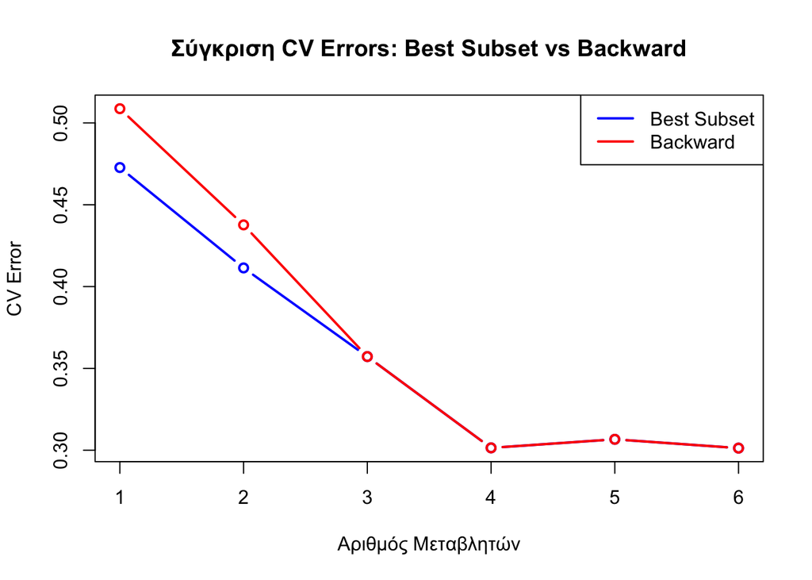

```r
plot(comparison_cv$Variables, comparison_cv$Best_Subset_CV,
     type = "b", col = "blue", lwd = 2,
     xlab = "Αριθμός Μεταβλητών", ylab = "CV Error",
     main = "Σύγκριση CV Errors: Best Subset vs Backward",
     ylim = range(c(comparison_cv$Best_Subset_CV, comparison_cv$Backward_CV)))
lines(comparison_cv$Variables, comparison_cv$Backward_CV,
      type = "b", col = "red", lwd = 2)
legend("topright", legend = c("Best Subset", "Backward"),
       col = c("blue", "red"), lwd = 2)
```

```r
best_subset_optimal <- which.min(comparison_cv$Best_Subset_CV)
backward_optimal <- which.min(comparison_cv$Backward_CV)

cat("Βέλτιστος αριθμός μεταβλητών - Best Subset:", best_subset_optimal, "\n")
```

```
## Βέλτιστος αριθμός μεταβλητών - Best Subset: 6
```

```r
cat("Βέλτιστος αριθμός μεταβλητών - Backward:", backward_optimal, "\n")
```

```
## Βέλτιστος αριθμός μεταβλητών - Backward: 6
```

Στην συνέχεια της ανάλυσης, πραγματοποιήσαμε σύγκριση μεταξύ των μεθόδων Best Subset και Backward Selection χρησιμοποιώντας Cross-Validation. Η διαδικασία αυτή είχε ως στόχο να αξιολογήσει την ευρωστία των αποτελεσμάτων και να εξετάσει εάν η επιλογή του βέλτιστου μοντέλου είναι ανεξάρτητη της μεθόδου που χρησιμοποιείται. Δημιουργήσαμε μια ειδική συνάρτηση predict για την Backward Selection και εφαρμόσαμε την ίδια ακριβώς διαδικασία Cross-Validation που είχαμε χρησιμοποιήσει και για το Best Subset, χρησιμοποιώντας το ίδιο seed και τα ίδια folds για να εξασφαλίσουμε τη συγκρισιμότητα των αποτελεσμάτων. Τα ευρήματα αποκάλυψαν μια σημαντική σύμπτωση μεταξύ των δύο μεθόδων, καθώς και οι δύο οδήγησαν στο ίδιο βέλτιστο μέγεθος μοντέλου των 6 μεταβλητών, με παρόμοιες καμπύλες CV errors. Αυτή η συμφωνία υποδηλώνει ότι τα δεδομένα μας έχουν ξεκάθαρη δομή που αναγνωρίζεται ανεξάρτητα από τη μέθοδο επιλογής και ενισχύει την αξιοπιστία της τελικής μας επιλογής μοντέλου. Η διαδικασία αυτή αποτελεί βέλτιστη πρακτική στη στατιστική μοντελοποίηση, καθώς εξασφαλίζει ότι τα συμπεράσματά μας βασίζονται σε σταθερές και αξιόπιστες στατιστικές βάσεις.

```r
coef(bss, p.cv)
```

```
##                  (Intercept)               GDP.per.capita
##                    1.7952202                    0.7753716
##               Social.support      Healthy.life.expectancy
##                    1.1241916                    1.0781427
## Freedom.to.make.life.choices                   Generosity
##                    1.4548324                    0.4897834
##    Perceptions.of.corruption
##                    0.9722802
```

Συμπερασματικά, με την μέθοδο βέλτιστου υποσυνόλου το Cross Validation υποδεικνύει ως βέλτιστο το πλήρες μοντέλο, όμως το μοντέλο μεγέθους 4 (χωρις Generosity και Perceptions of corruption) έχει εξήσου καλή προβλεψημότητα (διαφορά 0.047%). Τα καλύτερα μοντέλα με βάση τα κριτήρια Cp και AdjR2 είναι μεγέθους 5 με όλες τις μεταβλητές εκτός την Generosity και με BIC είναι μεγέθους 4 με όλες τις μεταβλητές εκτός απο τις Generosity και Perceptions of corruption.

Απο την θεωρία γνωρίζουμε ότι: - το AdjR2 επιλέγει το μοντέλο με την μέγιστη εξήγηση της μεταβλητότητας του Score, διορθωμένο για την πολυπλοκότητα, - το Cp επιλέγει μοντέλο που έχει χαμηλή μεροληψία στη διακύμανση, προτιμόντας τιμές κοντά στον αριθμό μεταβλητών (6), - το BIC επιβάλλει ισχυρή ποινή στην πολυπλοκότητα, (και οι τρείς μεθόδοι εξισσοροπούν ένα μέτρο καλής προσαρμογής στις παρατηρήσεις με ένα μέτρο στην πολυπλοκότητα). - το CV επιλέγει με βάση το μέσο σφάλμα πρόβλεψης.

Επίσης είδαμε ότι η μεταβλητή Generosity δεν είναι στατιστικά σημαντική (p>>0.05) και η Perceptions of corruption δεν είναι οριακά (p>0.05). Άρα η Generosity δεν συμβάλλει ουσιαστικά στην εξήγηση της μεταβλητότητας του Happiness Score.

Δεδομένου τα πιο πάνω, η επιλογή του τελικού μοντέλου εξαρτάται απο τα κριτήρια: -πρόβλεψη, πολυπλοκότητα και προσαρμογή.

Προσαρμόζουμε το μοντέλο μας με 4 μεταβλητές

```r
data4 = new_data[, c("Score", "GDP.per.capita", "Social.support",
                     "Healthy.life.expectancy", "Freedom.to.make.life.choices")]


lm.final <- lm(Score ~ ., data4)
summary(lm.final)
```

```
##
## Call:
## lm(formula = Score ~ ., data = data4)
##
## Residuals:
##      Min       1Q   Median       3Q      Max
## -1.86584 -0.34594  0.03403  0.43676  1.13076
##
## Coefficients:
##                              Estimate Std. Error t value Pr(>|t|)
## (Intercept)                    1.8921     0.1994   9.491  < 2e-16 ***
## GDP.per.capita                 0.8105     0.2165   3.745 0.000256 ***
## Social.support                 1.0166     0.2347   4.331 2.70e-05 ***
## Healthy.life.expectancy        1.1414     0.3373   3.384 0.000910 ***
## Freedom.to.make.life.choices   1.8458     0.3404   5.423 2.28e-07 ***
## ---
## Signif. codes:  0 '***' 0.001 '**' 0.01 '*' 0.05 '.' 0.1 ' ' 1
##
## Residual standard error: 0.5398 on 151 degrees of freedom
## Multiple R-squared:  0.7709, Adjusted R-squared:  0.7649
## F-statistic:   127 on 4 and 151 DF,  p-value: < 2.2e-16
```

```r
summary(lm.full)
```

```
##
## Call:
## lm(formula = Score ~ ., data = new_data)
##
## Residuals:
##      Min       1Q   Median       3Q      Max
## -1.75304 -0.35306  0.05703  0.36695  1.19059
##
## Coefficients:
##                              Estimate Std. Error t value Pr(>|t|)
## (Intercept)                    1.7952     0.2111   8.505 1.77e-14 ***
## GDP.per.capita                 0.7754     0.2182   3.553 0.000510 ***
## Social.support                 1.1242     0.2369   4.745 4.83e-06 ***
## Healthy.life.expectancy        1.0781     0.3345   3.223 0.001560 **
## Freedom.to.make.life.choices   1.4548     0.3753   3.876 0.000159 ***
## Generosity                     0.4898     0.4977   0.984 0.326709
## Perceptions.of.corruption      0.9723     0.5424   1.793 0.075053 .
## ---
## Signif. codes:  0 '***' 0.001 '**' 0.01 '*' 0.05 '.' 0.1 ' ' 1
##
## Residual standard error: 0.5335 on 149 degrees of freedom
## Multiple R-squared:  0.7792, Adjusted R-squared:  0.7703
## F-statistic: 87.62 on 6 and 149 DF,  p-value: < 2.2e-16
```

Προχωρήσαμε στη δημιουργία ενός μοντέλου με τις 4 πιο σημαντικές μεταβλητές που είχαν προκύψει από τις προηγούμενες διαδικασίες επιλογής. Αυτές οι μεταβλητές είναι το GDP per capita, η Social support, το Healthy life expectancy και η Freedom to make life choices. Το μοντέλο αυτό προσαρμόστηκε και τα αποτελέσματά του συγκρίθηκαν με αυτά του πλήρους μοντέλου που περιλαμβάνει και τις υπόλοιπες δύο μεταβλητές, την Generosity και την Perceptions of corruption. Από την σύγκριση των δύο μοντέλων, παρατηρούμε ότι το τελικό μοντέλο με τις 4 μεταβλητές έχει πολύ παρόμοια απόδοση με το πλήρες μοντέλο. Συγκεκριμένα, το Adjusted R-squared του μοντέλου με 4 μεταβλητές είναι 0.7649, ενώ του πλήρους μοντέλου είναι 0.7703, μια πολύ μικρή διαφορά που υποδηλώνει ότι οι δύο επιπλέον μεταβλητές δεν προσφέρουν σημαντική πρόσθετη εξήγηση της μεταβλητότητας του Happiness Score. Επίσης, το Residual standard error είναι παρόμοιο και στα δύο μοντέλα (0.5398 έναντι 0.5335), γεγονός που επιβεβαιώνει ότι η απλοποίηση του μοντέλου δεν επιφέρει σημαντική απώλεια ακρίβειας. Όλοι οι συντελεστές στο μοντέλο των 4 μεταβλητών είναι στατιστικά σημαντικοί (p-value < 0.001), γεγονός που ενισχύει την εγκυρότητα του μοντέλου. Συνολικά, η επιλογή του μοντέλου με τις 4 μεταβλητές δικαιολογείται πλήρως, αφού παρέχει μια πιο απλή και ερμηνεύσιμη λύση χωρίς να θυσιάζει την προβλεπτική του ικανότητα.

```r
cat("Προβλέψεις Full Model:\n")
```

```
## Προβλέψεις Full Model:
```

```r
predict(lm.full,interval="prediction")[1:20,]
```

```
##         fit      lwr      upr
## 1  7.005482 5.908776 8.102189
## 2  7.093064 5.999522 8.186606
## 3  7.177318 6.096921 8.257714
## 4  6.945013 5.864458 8.025568
## 5  6.923515 5.847557 7.999472
## 6  7.065252 5.985581 8.144922
## 7  6.958686 5.874539 8.042833
## 8  7.044242 5.955137 8.133348
## 9  6.954374 5.879416 8.029332
## 10 6.728920 5.662858 7.794983
## 11 6.971146 5.894746 8.047545
## 12 6.227913 5.157750 7.298076
## 13 6.277005 5.206107 7.347904
## 14 6.964053 5.883425 8.044682
## 15 6.727040 5.646634 7.807447
## 16 6.978492 5.899711 8.057274
## 17 6.664137 5.594775 7.733498
## 18 6.571137 5.506152 7.636122
## 19 6.408657 5.336421 7.480893
## 20 6.165122 5.094499 7.235744
```

```r
cat("\nΠροβλέψεις Final Model (4 variables):\n")
```

```
##
## Προβλέψεις Final Model (4 variables):
```

```r
predict(lm.final,interval="prediction")[1:20,]
```

```
##         fit      lwr      upr
## 1  6.817167 5.738641 7.895692
## 2  6.841819 5.763373 7.920265
## 3  6.992907 5.912371 8.073442
## 4  6.923632 5.844465 8.002799
## 5  6.739330 5.662396 7.816263
## 6  6.876971 5.798105 7.955837
## 7  6.739247 5.661452 7.817042
## 8  6.782032 5.703633 7.860431
## 9  6.792415 5.713910 7.870920
## 10 6.648597 5.572337 7.724858
## 11 6.788542 5.711289 7.865795
## 12 6.324319 5.245071 7.403567
## 13 6.264873 5.187838 7.341908
## 14 6.825881 5.742527 7.909236
## 15 6.503604 5.428724 7.578485
## 16 6.778653 5.700613 7.856692
## 17 6.523420 5.448303 7.598536
## 18 6.518722 5.444178 7.593265
## 19 6.370440 5.291810 7.449070
## 20 6.326053 5.252864 7.399241
```

```r
cat("\nΜέσο πλάτος Prediction Intervals:\n")
```

```
##
## Μέσο πλάτος Prediction Intervals:
```

```r
cat("Full model:", mean(predict(lm.full,interval="prediction")[,"upr"] -
                       predict(lm.full,interval="prediction")[,"lwr"]), "\n")
```

```
## Full model: 2.155094
```

```r
cat("Final model:", mean(predict(lm.final,interval="prediction")[,"upr"] -
                        predict(lm.final,interval="prediction")[,"lwr"]), "\n")
```

```
## Final model: 2.16671
```

Πραγματοποιήσαμε μια λεπτομερή σύγκριση των προβλέψεων που παράγουν τόσο το πλήρες μοντέλο όσο και το τελικό μοντέλο με τις 4 μεταβλητές. Από τα αποτελέσματα που προέκυψαν, παρατηρούμε ότι οι προβλεπόμενες τιμές για τις πρώτες 20 χώρες είναι εξαιρετικά κοντά μεταξύ των δύο μοντέλων, με ελάχιστες διαφορές που κυμαίνονται συνήθως λιγότερο από 0.2 μονάδες. Αυτή η εγγύτητα στις προβλέψεις επιβεβαιώνει ότι η αφαίρεση των δύο λιγότερο σημαντικών μεταβλητών δεν επηρεάζει σημαντικά την προβλεπτική ικανότητα του μοντέλου. Επιπλέον, η σύγκριση των διαστημάτων πρόβλεψης αποκαλύπτει μια πολύ σημαντική ομοιότητα: το μέσο πλάτος των διαστημάτων πρόβλεψης είναι 2.155094 για το πλήρες μοντέλο και 2.16671 για το τελικό μοντέλο, μια ασήμαντη διαφορά της τάξης του 0.5%. Αυτό δείχνει ότι η απλοποίηση του μοντέλου δεν αυξάνει την αβεβαιότητα των προβλέψεων, καθώς τα διαστήματα εμπιστοσύνης παραμένουν σχεδόν πανομοιότυπα. Η ελάχιστη αύξηση στο πλάτος των διαστημάτων του τελικού μοντέλου είναι αναμενόμενη και αποδεκτή, δεδομένης της μείωσης του αριθμού των παραμέτρων. Συνολικά, αυτά τα ευρήματα ενισχύουν περαιτέρω την απόφασή μας να υιοθετήσουμε το απλούστερο μοντέλο με τις 4 μεταβλητές, καθώς διατηρεί την ίδια ουσιαστική προβλεπτική ακρίβεια με το πλήρες μοντέλο, προσφέροντας ταυτόχρονα μεγαλύτερη ερμηνευσιμότητα και λιγότερη πολυπλοκότητα.

```r
final_model <- lm(Score ~ GDP.per.capita + Social.support +
                   Healthy.life.expectancy + Freedom.to.make.life.choices,
                 data = new_data)


country_analysis <- data.frame(
  Country = data$Country,  # Προσάρμοσε ανάλογα με τη δομή των δεδομένων σου
  Actual_Happiness = new_data$Score,
  Predicted_Happiness = predict(final_model),
  Residual = residuals(final_model)
)


country_analysis$Original_Rank <- rank(-country_analysis$Actual_Happiness)
country_analysis$Adjusted_Rank <- rank(-country_analysis$Residual)

country_analysis <- country_analysis[order(country_analysis$Adjusted_Rank), ]


cat("=== ΝΕΑ ΚΑΤΑΤΑΞΗ ΧΩΡΩΝ (με βάση τα υπόλοιπα) ===\n")
```

```
## === ΝΕΑ ΚΑΤΑΤΑΞΗ ΧΩΡΩΝ (με βάση τα υπόλοιπα) ===
```

```r
cat("Αυτή η κατάταξη δείχνει ποιες χώρες είναι πιο 'επιτυχημένες' σε σχέση\n")
```

```
## Αυτή η κατάταξη δείχνει ποιες χώρες είναι πιο 'επιτυχημένες' σε σχέση
```

```r
cat("με τα οικονομικά και κοινωνικά τους χαρακτηριστικά.\n\n")
```

```
## με τα οικονομικά και κοινωνικά τους χαρακτηριστικά.
```

```r
print(country_analysis[, c("Country", "Adjusted_Rank", "Original_Rank",
                          "Actual_Happiness", "Residual")])
```

```
##                      Country Adjusted_Rank Original_Rank Actual_Happiness
## 102                    Benin             1         102.0            4.883
## 67                  Pakistan             2          67.0            5.653
## 1                    Finland             3           1.0            7.769
## 13                    Israel             4          13.0            7.139
## 132                     Chad             5         132.0            4.350
## 99               Ivory Coast             6          99.0            4.944
## 12                Costa Rica             7          12.0            7.167
## 114                    Niger             8         114.0            4.628
## 27                 Guatemala             9          27.0            6.436
## 35               El Salvador            10          35.0            6.253
## 2                    Denmark            11           2.0            7.600
## 5                Netherlands            12           5.0            7.488
## 112                  Somalia            13         112.0            4.668
## 23                    Mexico            14          23.0            6.595
```

[output cut: 299 more lines]

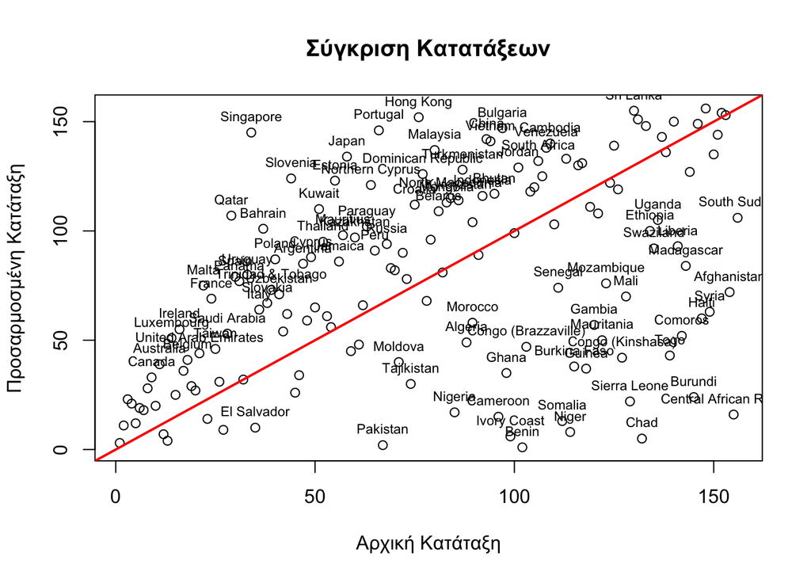

```r
# 4. Γραφική παράσταση
plot(country_analysis$Original_Rank, country_analysis$Adjusted_Rank,
     xlab = "Αρχική Κατάταξη", ylab = "Προσαρμοσμένη Κατάταξη",
     main = "Σύγκριση Κατατάξεων")
abline(0, 1, col = "red", lwd = 2)  # Διαγώνια γραμμή για σύγκριση

# Προσθήκη ονομάτων για ακραίες περιπτώσεις
extreme_cases <- country_analysis[abs(country_analysis$Original_Rank -
                                      country_analysis$Adjusted_Rank) > 20, ]
text(extreme_cases$Original_Rank, extreme_cases$Adjusted_Rank,
     labels = extreme_cases$Country, pos = 3, cex = 0.7)
```

Στην τελική φάση της ανάλυσής μας, πραγματοποιήσαμε μια εμβριθής ανάλυση κατάταξης των χωρών που βασίζεται στα υπόλοιπα του τελικού μας μοντέλου. Η προσέγγιση αυτή προσφέρει μια πολύ πιο ενδιαφέρουσα προοπτική από την απλή κατάταξη βάσει του Happiness Score, καθώς μας επιτρέπει να εντοπίσουμε ποιες χώρες είναι πιο “επιτυχημένες” ή “αποτυχημένες” σε σχέση με τα οικονομικά και κοινωνικά τους χαρακτηριστικά. Δημιουργήσαμε έναν πίνακα που περιλαμβάνει τόσο την πραγματική τιμή ευτυχίας κάθε χώρας όσο και την προβλεπόμενη τιμή από το μοντέλο μας, καθώς και τα αντίστοιχα υπόλοιπα. Η βασική ιδέα πίσω από αυτή την ανάλυση είναι ότι τα υπόλοιπα αντιπροσωπεύουν το “ανεξήγητο” μέρος της ευτυχίας μιας χώρας - δηλαδή, πόσο υψηλότερη ή χαμηλότερη είναι η πραγματική ευτυχία σε σχέση με αυτή που θα περιμέναμε βάσει των αντικειμενικών δεικτών της.

Η γραφική παράσταση σύγκρισης των δύο κατατάξεων αποκαλύπτει ενδιαφέροντα μοτίβα. Οι χώρες που βρίσκονται μακριά από τη διαγώνιο γραμμή αναπαριστούν ενδιαφέρουσες περιπτώσεις για περαιτέρω διερεύνηση. Χώρες που βελτιώνουν σημαντικά τη θέση τους στη νέα κατάταξη μπορεί να αποτελούν “επιτυχημένες περιπτώσεις” που καταφέρνουν να επιτύχουν υψηλότερη ευτυχία από αυτή που θα προβλεπόταν από τα διαθέσιμα δεδομένα. Αντίθετα, χώρες που χειροτερεύουν σημαντικά τη θέση τους μπορεί να αντιμετωπίζουν προκλήσεις ή να έχουν χαρακτηριστικά που εμποδίζουν την επίτευξη της ευτυχίας που θα αναμέναμε βάσει των ποσοτικών δεικτών τους. Αυτή η ανάλυση ανοίγει το δρόμο για περαιτέρω ποιοτική έρευνα στις χώρες που εμφανίζουν τις μεγαλύτερες αποκλίσεις, ώστε να κατανοήσουμε τους λόγους πίσω από αυτές τις διαφορές και να εξαγάγουμε πολύτιμα μαθήματα για τις πολιτικές που προωθούν την ευτυχία.